# EP02

Alfonso Palacios y Nicolás Sarabia

2025-08-28

# **Equipo 7:**

### 1. El Comité Olímpico cree que el mejor tiempo medio de los atletas de la zona Sur después de ingresar al programa de entrenamiento es 12,9 segundos. ¿Soportan los datos esta afirmación?

### 2. ¿Sugieren los datos que la mejor marca de los atletas de la zona Centro-Norte se reduce en promedio menos de 2,8 segundos tras el entrenamiento?

### 3. ¿Es posible afirmar que, en promedio, los atletas de la zona Centro-Norte superan a los de la zona Centro-Sur por más de 1,6 segundos después del entrenamiento?

### 4.¿Será cierto que hay más atletas de la zona Centro-Sur que redujeron sus mejores marcas en al menos 4,7 segundos que atletas de la zona Sur que lo hicieron en al menos 1,7 segundos?

## Pregunta 1

El Comité Olímpico cree que el mejor tiempo medio de los atletas de la zona Sur después de ingresar al programa de entrenamiento es 12,9 segundos. ¿Soportan los datos esta afirmación?

Para responder esta pregunta inicialmente se filtran los datos para quedarse solo con los atletas de la zona Sur.

```r
library(dplyr)
datos <- read.csv2("EP02 Datos.csv")
datos_sur = datos %>%
  filter(Zona=="Sur")
```

Se define la Hipotesis nula y alternativa para codimar en base a lo planteado por el comite.
$$H_o: \mu=12.9 \newline H_a: \mu \ne 12.9$$

Verificar si los datos son normales, para lo cual se utiliza la prueba de Shapiro.

```r
mean <- mean(datos_sur$Posterior)
print("Promedio a tiempos posterior: ", mean)
```

```
## [1] "Promedio a tiempos posterior: "
```

```r
dim(datos_sur)
```

```
## [1] 28  4
```

```r
nortest <- shapiro.test(datos_sur$Posterior)
nortest
```

```
##
##  Shapiro-Wilk normality test
##
## data:  datos_sur$Posterior
## W = 0.95201, p-value = 0.2225
```

```r
test <- t.test(datos_sur$Posterior, alternative = "two.sided", conf.level = 0.95, mu = 12.9)
test
```

```
##
##  One Sample t-test
##
## data:  datos_sur$Posterior
## t = -1.4861, df = 27, p-value = 0.1488
## alternative hypothesis: true mean is not equal to 12.9
## 95 percent confidence interval:
##  12.06039 13.03425
## sample estimates:
## mean of x
##  12.54732
```

Dado que el p-value de la prueba de Shapiro es mayor a 0.05, se puede asumir normalidad en los datos. Por otro lado, el p-value del test t es mayor a 0.05, por lo que, no existe suficiente evidencia para rechazar la hipotesis nula.

## Pregunta 2

¿Sugieren los datos que la mejor marca de los atletas de la zona Centro-Norte se reduce en promedio menos de 2,8 segundos tras el entrenamiento?

Para responder a esta pregunta, se filtran los datos para quedarse solo con los atletas de la zona Centro-Norte.

```r
datos_centro_norte <- datos %>%
  filter(Zona=="Centro-Norte")

datos_cn_post <- datos_centro_norte$Posterior
datos_cn_prev <- datos_centro_norte$Previo

prev_menos_post <- datos_cn_prev - datos_cn_post
```

Se define la Hipotesis nula y alternativa para codimar en base a lo planteado por el comite.

$$H_o: \mu=2.8 \newline H_a: \mu < 2.8$$

La hipotesis nula dice que la mejor marca de los atletas de la zona Centro-Norte se reduce en promedio 2.8 segundos tras el entrenamiento, mientras que la hipotesis alternativa dice que se reduce en promedio menos de 2.8 segundos tras el entrenamiento.

Se realiza la prueba de normalidad para los datos previos y posteriores, y se grafica el QQ plot de la diferencia entre ambos.

```r
if (shapiro.test(datos_cn_post)$p.value > 0.05 && shapiro.test(datos_cn_prev)$p.value > 0.05){
  cat("La prueba de normalidad fue exitosa")
}
```

```
## La prueba de normalidad fue exitosa
```

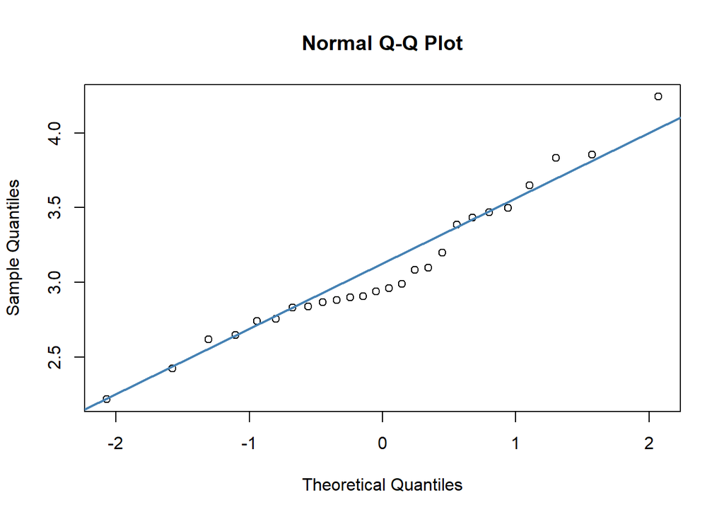

```r
qqnorm(prev_menos_post)
qqline(prev_menos_post, lwd = 2, col = "steelblue")
```

Dado que el p-value de la prueba de Shapiro es mayor a 0.05, se puede asumir normalidad en los datos.

Se realiza la prueba t.

```r
test <- t.test(prev_menos_post, mu = 2.8, alternative = "less", conf.level = 0.975)
test
```

```
##
##  One Sample t-test
##
## data:  prev_menos_post
## t = 3.1128, df = 25, p-value = 0.9977
## alternative hypothesis: true mean is less than 2.8
## 97.5 percent confidence interval:
##      -Inf 3.276253
## sample estimates:
## mean of x
##  3.086615
```

Dado que el p-value es 0.997, no se rechaza la hipótesis nula, ya que los datos no sugieren reducción de los tiempos es menor a 2,8 segundos. En conclusión, los datos no sugieren que la mejor marca de los atletas de la zona Centro-Norte se reduce en promedio menos de 2,8 segundos tras el entrenamiento.

## Pregunta 3

¿Es posible afirmar que, en promedio, los atletas de la zona Centro-Norte superan a los de la zona Centro-Sur por más de 1,6 segundos después del entrenamiento?

Para responder a esta pregunta, se filtran los datos para quedarse solo con los atletas de la zona Centro-Sur.

```r
datos_centro_sur <- datos %>%
  filter(Zona=="Centro-Sur")

datos_cs_post <- datos_centro_sur$Posterior

if(shapiro.test(datos_cs_post)$p.value > 0.05){
  cat("La prueba de normalidad fue exitosa")
}
```

```
## La prueba de normalidad fue exitosa
```

Se define la Hipotesis nula y alternativa para codimar en base a lo planteado por el comite.

$$H_o: \mu<1.6 \newline H_a: \mu \geq 1.6$$

```r
# NO son datos pareados
test <- t.test(x = datos_cs_post, y = datos_cn_post, mu = 1.6, alternative = "greater", paired = F, conf.level = 0.975)
test
```

```
##
##  Welch Two Sample t-test
##
## data:  datos_cs_post and datos_cn_post
## t = -1.0595, df = 50.639, p-value = 0.8528
## alternative hypothesis: true difference in means is greater than 1.6
## 97.5 percent confidence interval:
##  0.7781636       Inf
## sample estimates:
## mean of x mean of y
##  14.68333  13.36719
```

## Pregunta 4

¿Será cierto que hay más atletas de la zona Centro-Sur que redujeron sus mejores marcas en al menos 4,7 segundos que atletas de la zona Sur que lo hicieron en al menos 1,7 segundos?

Se pregunta si es que una proporción es mayor a otra. Por ende, se debe usar el método de Wald para dos proporciones, de una cola, para verificar si la proporción de atletas de la zona que redujeron sus mejores marcas en al menos 4,7 segundos es mayor que aquella de atletas de la zona Sur que lo hicieron en al menos 1,7 segundos Centro-Sur.

Hipótesis: (P: proporción)

$$H_o: PCentroSur - PSur \leq 0 \newline
H_a: PCentroSur - PSur > 0$$
La hipótesis nula indica que la proporción de atletas de Centro-Sur que redujeron sus marcas en >= 4.7 segundos es menor o igual a la proporción de atletas de Sur que lo hicieron en >= 1.7 segundos, mientras que la alternativa indica lo contrario.

Se procede a realizar el estudio con el método de Wald

```r
datos_sur_4.7 <- datos_sur %>%
  filter((Previo - Posterior) >= 1.7)
datos_centro_sur_1.7 <- datos_centro_sur %>%
  filter((Previo - Posterior) >= 4.7)

x1 <- nrow(datos_centro_sur_1.7)
n1 <- nrow(datos_centro_sur)

x2 <- nrow(datos_sur_4.7)
n2 <- nrow(datos_sur)

prop.test(c(x1,x2), c(n1,n2), alternative="greater", correct=F)
```

```
##
##  2-sample test for equality of proportions without continuity correction
##
## data:  c(x1, x2) out of c(n1, n2)
## X-squared = 8.6878, df = 1, p-value = 0.001602
## alternative hypothesis: greater
## 95 percent confidence interval:
##  0.1893074 1.0000000
## sample estimates:
##    prop 1    prop 2
## 0.8148148 0.4285714
```

Ya que el p-valor es del estudio es menor a 0.05, podemos inclinarnos a favor de la hipótesis alternativa. Los datos proporcionan evidencia estadística sólida para concluir que la proporción de atletas de la zona Centro-Sur que lograron reducir sus mejores marcas en al menos 4.7 segundos es significativamente mayor que la proporción de atletas de la zona Sur que alcanzaron una reducción de al menos 1.7 segundos.